# STAT 540 Seminar 07: RNA-seq - Differential Expression Analysis

## STAT 540 Seminar 07: RNA-seq - Differential Expression Analysis

**2014-03-01**

- Repeat the examples in the seminar
  - edgeR
  - Mini exercise
  - DESeq
  - Voom & limma
- Take-home exercise

> The R markdown file can be found on my [Github](https://github.com/nelsonch/stat540-2014-chen-hao/blob/master/seminar%2007/seminar07.Rmd).

### Repeat the examples in the seminar

#### edgeR

Install the edgeR package from Bioconductor.

```r
> source("http://bioconductor.org/biocLite.R")
> biocLite("edgeR")
```

```r
> library(edgeR)
```

The following data files will be used in this seminar:

- bottomly_count_table.tsv: Data file
- bottomly_phenodata.tsv: Design file

```r
> dat <- read.table("bottomly_count_table.tsv", header = TRUE, row.names = 1)
> des <- read.table("bottomly_phenodata.tsv", header = TRUE, row.names = 1)
> str(dat)
```

```
'data.frame':   36536 obs. of  21 variables:
 $ SRX033480: int  369 0 0 0 0 0 21 15 517 0 ...
 $ SRX033488: int  744 0 1 0 1 1 46 43 874 0 ...
 $ SRX033481: int  287 0 0 0 1 0 20 12 340 0 ...
 $ SRX033489: int  769 0 1 0 5 1 36 34 813 0 ...
 $ SRX033482: int  348 0 1 0 0 0 12 14 378 0 ...
 $ SRX033490: int  803 0 1 0 4 0 55 32 860 0 ...
 $ SRX033483: int  433 0 0 0 0 0 27 19 528 0 ...
 $ SRX033476: int  469 0 7 0 0 0 44 18 401 0 ...
 $ SRX033478: int  585 0 6 0 0 0 32 44 584 0 ...
 $ SRX033479: int  321 0 1 0 0 0 47 22 401 0 ...
 $ SRX033472: int  301 0 1 0 4 0 40 17 331 0 ...
 $ SRX033473: int  461 0 1 0 1 0 40 24 431 0 ...
 $ SRX033474: int  309 0 1 0 1 0 30 29 341 0 ...
 $ SRX033475: int  374 0 1 0 0 0 27 15 480 0 ...
 $ SRX033491: int  781 0 1 0 1 0 46 34 930 0 ...
 $ SRX033484: int  555 0 2 0 2 0 28 23 585 0 ...
 $ SRX033492: int  820 0 1 0 1 0 40 38 1137 0 ...
 $ SRX033485: int  294 0 1 0 1 0 21 17 490 0 ...
 $ SRX033493: int  758 0 4 0 1 0 52 29 1079 0 ...
 $ SRX033486: int  419 0 1 0 1 0 27 12 565 0 ...
 $ SRX033494: int  857 0 5 0 2 0 45 28 726 0 ...
```

```r
> show(des)
```

```
          num.tech.reps   strain experiment.number lane.number
SRX033480             1 C57BL/6J                 6           1
SRX033488             1 C57BL/6J                 7           1
SRX033481             1 C57BL/6J                 6           2
SRX033489             1 C57BL/6J                 7           2
SRX033482             1 C57BL/6J                 6           3
SRX033490             1 C57BL/6J                 7           3
SRX033483             1 C57BL/6J                 6           5
SRX033476             1 C57BL/6J                 4           6
SRX033478             1 C57BL/6J                 4           7
SRX033479             1 C57BL/6J                 4           8
SRX033472             1   DBA/2J                 4           1
SRX033473             1   DBA/2J                 4           2
SRX033474             1   DBA/2J                 4           3
SRX033475             1   DBA/2J                 4           5
SRX033491             1   DBA/2J                 7           5
SRX033484             1   DBA/2J                 6           6
SRX033492             1   DBA/2J                 7           6
SRX033485             1   DBA/2J                 6           7
SRX033493             1   DBA/2J                 7           7
SRX033486             1   DBA/2J                 6           8
SRX033494             1   DBA/2J                 7           8
```

```r
> all(rownames(des) == colnames(dat))
```

```
[1] TRUE
```

```r
> with(des, table(strain))
```

```
strain
C57BL/6J   DBA/2J
      10       11
```

```r
> group <- factor(c(rep("1", 10), rep("2", 11)))
> dge.glm <- DGEList(counts = dat, group = group)
> str(dge.glm)
```

```
Formal class 'DGEList' [package "edgeR"] with 1 slots
  ..@ .Data:List of 2
  .. ..$ : int [1:36536, 1:21] 369 0 0 0 0 0 21 15 517 0 ...
  .. .. ..- attr(*, "dimnames")=List of 2
  .. .. .. ..$ : chr [1:36536] "ENSMUSG00000000001" "ENSMUSG00000000003" "ENSMUSG00000000028" "ENSMUSG00000000031" ...
  .. .. .. ..$ : chr [1:21] "SRX033480" "SRX033488" "SRX033481" "SRX033489" ...
  .. ..$ :'data.frame': 21 obs. of  3 variables:
  .. .. ..$ group       : Factor w/ 2 levels "1","2": 1 1 1 1 1 1 1 1 1 1 ...
  .. .. ..$ lib.size    : num [1:21] 3040296 6303665 2717092 6545795 3016179 ...
  .. .. ..$ norm.factors: num [1:21] 1 1 1 1 1 1 1 1 1 1 ...
```

> This produces an object of type DGEList with can be manipulated in a similar way to any other list object in R.

```r
> names(dge.glm)
```

```
[1] "counts"  "samples"
```

```r
> dge.glm[["samples"]]
```

```
          group lib.size norm.factors
SRX033480     1  3040296            1
SRX033488     1  6303665            1
SRX033481     1  2717092            1
SRX033489     1  6545795            1
SRX033482     1  3016179            1
SRX033490     1  7097379            1
SRX033483     1  3707895            1
SRX033476     1  5165144            1
SRX033478     1  4953201            1
SRX033479     1  4192872            1
SRX033472     2  3970729            1
SRX033473     2  4733003            1
SRX033474     2  3702051            1
SRX033475     2  3569483            1
SRX033491     2  7276198            1
SRX033484     2  4422272            1
SRX033492     2  7115851            1
SRX033485     2  3467730            1
SRX033493     2  7339817            1
SRX033486     2  3879114            1
SRX033494     2  6771680            1
```

- This DGELIst object has two components, one is a matrix call 'counts' storing the count data.
- The other is a data.frame called 'samples' storing information for samples', including the samples IDs, group information and library sizes (or equally library sequence depth). You can either supply the library size info or it can be calculated from the sums of counts in each column.
- You can also provide an annotation file for the genes which will be stored in the data.frame 'genes'.

```r
> design <- model.matrix(~ group)
> design
```

```
   (Intercept) group2
1            1      0
2            1      0
3            1      0
4            1      0
5            1      0
6            1      0
7            1      0
8            1      0
9            1      0
10           1      0
11           1      1
12           1      1
13           1      1
14           1      1
15           1      1
16           1      1
17           1      1
18           1      1
19           1      1
20           1      1
21           1      1
attr(,"assign")
[1] 0 1
attr(,"contrasts")
attr(,"contrasts")$group
[1] "contr.treatment"
```

```r
> dge.glm.com.disp <- estimateGLMCommonDisp(dge.glm, design, verbose = TRUE)
```

```
Disp = 0.03893 , BCV = 0.1973
```

```r
> names(dge.glm.com.disp)
```

```
[1] "counts"            "samples"           "AveLogCPM"
[4] "common.dispersion" "design"
```

```r
> dge.glm.trend.disp <- estimateGLMTrendedDisp(dge.glm.com.disp, design)
> names(dge.glm.trend.disp)
```

```
[1] "counts"             "samples"            "AveLogCPM"
[4] "common.dispersion"  "design"             "trended.dispersion"
[7] "trend.method"       "bin.dispersion"     "bin.AveLogCPM"
```

```r
> dge.glm.tag.disp <- estimateGLMTagwiseDisp(dge.glm.trend.disp, design)
> str(dge.glm.tag.disp)
```

```
Formal class 'DGEList' [package "edgeR"] with 1 slots
  ..@ .Data:List of 12
  .. ..$ : int [1:36536, 1:21] 369 0 0 0 0 0 21 15 517 0 ...
  .. .. ..- attr(*, "dimnames")=List of 2
  .. .. .. ..$ : chr [1:36536] "ENSMUSG00000000001" "ENSMUSG00000000003" "ENSMUSG00000000028" "ENSMUSG00000000031" ...
  .. .. .. ..$ : chr [1:21] "SRX033480" "SRX033488" "SRX033481" "SRX033489" ...
  .. ..$ :'data.frame': 21 obs. of  3 variables:
  .. .. ..$ group       : Factor w/ 2 levels "1","2": 1 1 1 1 1 1 1 1 1 1 ...
  .. .. ..$ lib.size    : num [1:21] 3040296 6303665 2717092 6545795 3016179 ...
  .. .. ..$ norm.factors: num [1:21] 1 1 1 1 1 1 1 1 1 1 ...
  .. ..$ : num [1:36536] 6.734 -1.294 -0.385 -1.294 -0.602 ...
  .. ..$ : num 0.0389
  .. ..$ : num [1:21, 1:2] 1 1 1 1 1 1 1 1 1 1 ...
  .. .. ..- attr(*, "dimnames")=List of 2
  .. .. .. ..$ : chr [1:21] "1" "2" "3" "4" ...
  .. .. .. ..$ : chr [1:2] "(Intercept)" "group2"
  .. .. ..- attr(*, "assign")= int [1:2] 0 1
  .. .. ..- attr(*, "contrasts")=List of 1
  .. .. .. ..$ group: chr "contr.treatment"
  .. ..$ : num [1:36536] 0.0311 1.0941 0.3715 1.0941 0.4997 ...
  .. ..$ : chr "bin.spline"
  .. ..$ : num [1:45] 1.04e-07 3.83 1.05 2.26 1.26 ...
  .. ..$ : num [1:45] -1.26 -1.25 -1.23 -1.2 -1.15 ...
  .. ..$ : num 10
  .. ..$ : num 0.152
  .. ..$ : num [1:36536] 0.0244 1.0941 0.3621 1.0941 0.3713 ...
```

```r
> names(dge.glm.tag.disp)
```

```
 [1] "counts"             "samples"            "AveLogCPM"
 [4] "common.dispersion"  "design"             "trended.dispersion"
 [7] "trend.method"       "bin.dispersion"     "bin.AveLogCPM"
[10] "prior.df"           "span"               "tagwise.dispersion"
```

> `dge.glm.tag.disp` incoporates all the materials in `dge.glm.com.disp` and `dge.glm.trend.disp`.

Plot the tagwise dispersion against log2-CPM (counts per million)

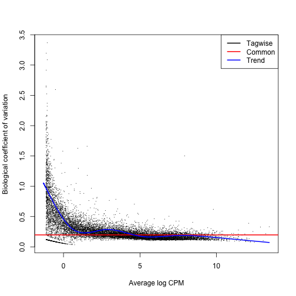

```r
> plotBCV(dge.glm.tag.disp)
```

Fit the model.

```r
> fit <- glmFit(dge.glm.tag.disp, design)
> colnames(coef(fit))
```

```
[1] "(Intercept)" "group2"
```

```r
> lrt <- glmLRT(fit, coef = 2)
> topTags(lrt)
```

```
Coefficient:  group2
                    logFC logCPM    LR    PValue       FDR
ENSMUSG00000020912 -5.187  3.155 401.8 2.238e-89 8.177e-85
ENSMUSG00000050141 -5.363  2.319 311.6 9.787e-70 1.788e-65
ENSMUSG00000035775 -4.543  2.674 298.0 9.042e-67 1.101e-62
ENSMUSG00000015484 -1.968  4.307 282.5 2.113e-63 1.930e-59
ENSMUSG00000024248 -3.152  3.463 277.0 3.337e-62 2.438e-58
ENSMUSG00000030532  1.547  5.572 269.4 1.568e-60 9.548e-57
ENSMUSG00000054354 -6.283  1.940 249.3 3.657e-56 1.909e-52
ENSMUSG00000023236  1.426  7.067 245.0 3.133e-55 1.431e-51
ENSMUSG00000050824  3.705  3.365 229.7 7.099e-52 2.882e-48
ENSMUSG00000015852 -2.362  3.138 214.8 1.210e-48 4.049e-45
```

```r
> tt.glm <- topTags(lrt, n = Inf)
> class(tt.glm)
```

```
[1] "TopTags"
attr(,"package")
[1] "edgeR"
```

```r
> names(tt.glm)
```

```
[1] "table"         "adjust.method" "comparison"    "test"
```

```r
> nrow(tt.glm$table[tt.glm$table$FDR < 0.01, ])
```

```
[1] 600
```

```r
> interestingSamples <- rownames(tt.glm$table[tt.glm$table$FDR < 1e-50, ])
> cpm(dge.glm.tag.disp)[interestingSamples, ]
```

```
                   SRX033480 SRX033488 SRX033481 SRX033489 SRX033482
ENSMUSG00000020912     20.39    12.691     15.83    14.819    19.230
ENSMUSG00000050141     14.14    10.153     10.67     6.264     9.946
ENSMUSG00000035775     14.47    10.629     19.51    11.305    12.930
ENSMUSG00000015484     26.97    33.949     32.76    36.206    31.497
ENSMUSG00000024248     14.80    26.017     17.30    23.527    18.567
ENSMUSG00000030532     27.96    24.906     21.35    25.360    18.567
ENSMUSG00000054354     10.85     7.615     11.41     8.708     8.289
ENSMUSG00000023236     65.45    78.684     72.50    72.413    76.587
                   SRX033490 SRX033483 SRX033476 SRX033478 SRX033479
ENSMUSG00000020912    17.330    26.430    13.359    23.621    14.310
ENSMUSG00000050141     7.890     8.361     6.583    11.911    12.402
ENSMUSG00000035775    12.540    12.136     6.389    13.527    11.210
ENSMUSG00000015484    33.393    30.745    34.655    26.851    31.482
ENSMUSG00000024248    25.784    18.879    24.781    14.334    14.310
ENSMUSG00000030532    26.770    26.430    19.167    23.217    20.034
ENSMUSG00000054354     7.608     7.012     3.291     4.442     5.963
ENSMUSG00000023236    80.875    83.336    55.178    57.740    66.303
                   SRX033472 SRX033473 SRX033474 SRX033475 SRX033491
ENSMUSG00000020912    0.5037    0.4226    1.0805    0.2802    1.0995
ENSMUSG00000050141    0.2518    0.0000    0.0000    0.2802    0.8246
ENSMUSG00000035775    0.7555    0.0000    0.2701    0.2802    0.6872
ENSMUSG00000015484    7.0516    4.8595    9.1841    7.8443    8.5209
ENSMUSG00000024248    2.2666    1.2677    1.8908    3.3618    3.1610
ENSMUSG00000030532   69.7605   70.5683   63.2082   63.0343   73.8023
ENSMUSG00000054354    0.0000    0.0000    0.0000    0.0000    0.5497
ENSMUSG00000023236  195.4301  183.6044  176.1186  156.3252  206.9762
                   SRX033484 SRX033492 SRX033485 SRX033493 SRX033486
ENSMUSG00000020912    0.0000    0.7027    0.8651    0.1362    0.0000
ENSMUSG00000050141    0.0000    0.1405    0.0000    0.1362    0.2578
ENSMUSG00000035775    0.6784    0.1405    0.5767    0.1362    1.8045
ENSMUSG00000015484    9.4974    8.4319    8.9396    6.6759   10.3116
ENSMUSG00000024248    1.5829    1.6864    1.7302    1.7712    2.5779
ENSMUSG00000030532   70.0997   70.6873   62.5770   78.6123   59.2919
ENSMUSG00000054354    0.0000    0.0000    0.0000    0.0000    0.0000
ENSMUSG00000023236  177.9628  192.8090  207.0519  201.6399  204.6859
                   SRX033494
ENSMUSG00000020912    0.0000
ENSMUSG00000050141    0.1477
ENSMUSG00000035775    0.5907
ENSMUSG00000015484    8.8604
ENSMUSG00000024248    3.1012
ENSMUSG00000030532   71.3265
ENSMUSG00000054354    0.0000
ENSMUSG00000023236  192.7144
```

```r
> summary(de.glm <- decideTestsDGE(lrt, p = 0.05, adjust = "BH"))
```

```
   [,1]
-1   451
0  35660
1    425
```

- 451 genes are under-expressed in group 2 (DBA/2J) compared with group 1 (C57BL/6J), 35660 show no differences in expression while 425 genes are over-expressed.

Plot the tagwise log fold changes against log-cpm

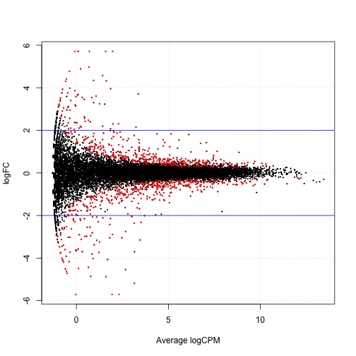

```r
> tags.glm <- rownames(dge.glm.tag.disp)[as.logical(de.glm)]
> plotSmear(lrt, de.tags = tags.glm)
> abline(h = c(-2, 2), col = "blue")
```

#### Mini exercise

Redo the above analysis but first filter the data and remove any gene that has: 1. count equal tot zero across all samples 2. count equal to zero in at least one sample in each genotype group

(1) Remove genes.

```r
> strain1 <- rownames(des)[des$strain == "C57BL/6J"]
> strain2 <- rownames(des)[des$strain == "DBA/2J"]
> datMin <- data.frame(MinStrain1 = unlist(apply(as.matrix(subset(dat, select = strain1)), 1, min)),
+                      MinStrain2 = unlist(apply(as.matrix(subset(dat, select = strain2)), 1, min)))
> rownames(datMin) <- rownames(dat)
> keepRow <- rownames(datMin)[datMin$MinStrain1 > 0 | datMin$MinStrain2 > 0]
> datClean <- dat[keepRow, ]
> str(datClean, list.len = 5)
```

```
'data.frame':   9973 obs. of  21 variables:
 $ SRX033480: int  369 0 21 15 517 273 11 19 19 97 ...
 $ SRX033488: int  744 1 46 43 874 781 24 29 24 194 ...
 $ SRX033481: int  287 0 20 12 340 275 13 27 19 51 ...
 $ SRX033489: int  769 1 36 34 813 745 34 110 42 101 ...
 $ SRX033482: int  348 1 12 14 378 301 27 27 22 67 ...
  [list output truncated]
```

(2) Redo the analysis

> Variables `group` and `design` remain unchanged.

```r
> dge.glm.clean <- DGEList(counts = datClean, group = group)
> dge.glm.com.disp.clean <- estimateGLMCommonDisp(dge.glm.clean, design, verbose = TRUE)
```

```
Disp = 0.0383 , BCV = 0.1957
```

```r
> dge.glm.trend.disp.clean <- estimateGLMTrendedDisp(dge.glm.com.disp.clean, design)
> dge.glm.tag.disp.clean <- estimateGLMTagwiseDisp(dge.glm.trend.disp.clean, design)
```

Plot the tagwise dispersion against log2-CPM.

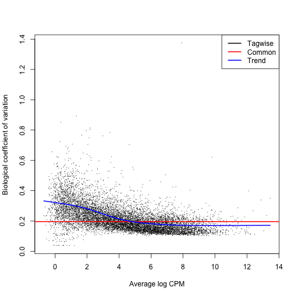

```r
> plotBCV(dge.glm.tag.disp.clean)
```

```r
> fit.clean <- glmFit(dge.glm.tag.disp.clean, design)
> lrt.clean <- glmLRT(fit.clean, coef = 2)
> tt.glm.clean <- topTags(lrt.clean, n = Inf)
> (n <- nrow(tt.glm.clean$table[tt.glm.clean$table$FDR < 0.01, ]))
```

```
[1] 731
```

- 731 genes have a FDR less than 0.01.

```r
> summary(de.glm.clean <- decideTestsDGE(lrt.clean, p = 0.05, adjust = "BH"))
```

```
   [,1]
-1  589
0  8773
1   611
```

Plot the tagwise log fold changes against log-cpm

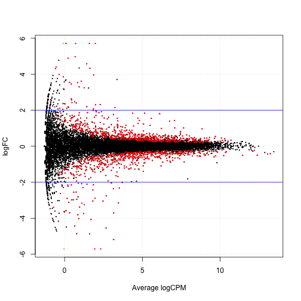

```r
> tags.glm.clean <- rownames(dge.glm.tag.disp.clean)[as.logical(de.glm.clean)]
> plotSmear(lrt, de.tags = tags.glm.clean)
> abline(h = c(-2, 2), col = "blue")
```

#### DESeq

Try the differential expression analysis of the same dataset using DESeq.

```r
> source("http://www.bioconductor.org/biocLite.R")
> biocLite("DESeq")
```

```r
> library(DESeq)
```

Read in the same count table data and grouping information

```r
> deSeqDat <- newCountDataSet(dat, group)
> head(counts(deSeqDat))
```

```
                   SRX033480 SRX033488 SRX033481 SRX033489 SRX033482
ENSMUSG00000000001       369       744       287       769       348
ENSMUSG00000000003         0         0         0         0         0
ENSMUSG00000000028         0         1         0         1         1
ENSMUSG00000000031         0         0         0         0         0
ENSMUSG00000000037         0         1         1         5         0
ENSMUSG00000000049         0         1         0         1         0
                   SRX033490 SRX033483 SRX033476 SRX033478 SRX033479
ENSMUSG00000000001       803       433       469       585       321
ENSMUSG00000000003         0         0         0         0         0
ENSMUSG00000000028         1         0         7         6         1
ENSMUSG00000000031         0         0         0         0         0
ENSMUSG00000000037         4         0         0         0         0
ENSMUSG00000000049         0         0         0         0         0
                   SRX033472 SRX033473 SRX033474 SRX033475 SRX033491
ENSMUSG00000000001       301       461       309       374       781
ENSMUSG00000000003         0         0         0         0         0
ENSMUSG00000000028         1         1         1         1         1
ENSMUSG00000000031         0         0         0         0         0
ENSMUSG00000000037         4         1         1         0         1
ENSMUSG00000000049         0         0         0         0         0
                   SRX033484 SRX033492 SRX033485 SRX033493 SRX033486
ENSMUSG00000000001       555       820       294       758       419
ENSMUSG00000000003         0         0         0         0         0
ENSMUSG00000000028         2         1         1         4         1
ENSMUSG00000000031         0         0         0         0         0
ENSMUSG00000000037         2         1         1         1         1
ENSMUSG00000000049         0         0         0         0         0
                   SRX033494
ENSMUSG00000000001       857
ENSMUSG00000000003         0
ENSMUSG00000000028         5
ENSMUSG00000000031         0
ENSMUSG00000000037         2
ENSMUSG00000000049         0
```

Estimate the size factors to account for differences in library coverage and estimate the variance:

```r
> deSeqDat <- estimateSizeFactors(deSeqDat)
> sizeFactors(deSeqDat)
```

```
SRX033480 SRX033488 SRX033481 SRX033489 SRX033482 SRX033490 SRX033483
   0.6439    1.3454    0.5785    1.4295    0.6355    1.5240    0.7933
SRX033476 SRX033478 SRX033479 SRX033472 SRX033473 SRX033474 SRX033475
   1.1272    1.0772    0.8984    0.8886    1.0255    0.7987    0.7796
SRX033491 SRX033484 SRX033492 SRX033485 SRX033493 SRX033486 SRX033494
   1.6162    0.9882    1.5720    0.7558    1.5922    0.8264    1.4715
```

```r
> deSeqDat <- estimateDispersions(deSeqDat)
```

Plot the estimated dispersions against the mean normalized counts

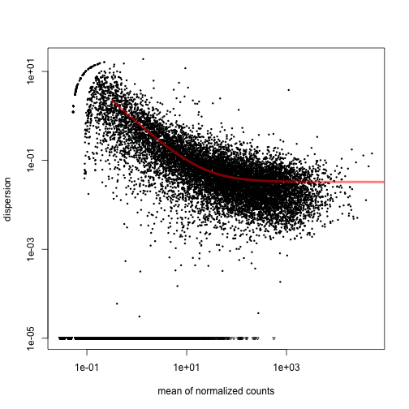

```r
> plotDispEsts(deSeqDat)
```

Fit the model and examine the results

```r
> results <- nbinomTest(deSeqDat, levels(group)[1], levels(group)[2])
> str(results)
```

```
'data.frame':   36536 obs. of  8 variables:
 $ id            : chr  "ENSMUSG00000000001" "ENSMUSG00000000003" "ENSMUSG00000000028" "ENSMUSG00000000031" ...
 $ baseMean      : num  489.18 0 1.57 0 1.1 ...
 $ baseMeanA     : num  509.685 0 1.657 0 0.859 ...
 $ baseMeanB     : num  470.53 0 1.49 0 1.32 ...
 $ foldChange    : num  0.923 NaN 0.898 NaN 1.537 ...
 $ log2FoldChange: num  -0.115 NaN -0.156 NaN 0.62 ...
 $ pval          : num  0.498 NA 0.829 NA 0.968 ...
 $ padj          : num  1 NA 1 NA 1 ...
```

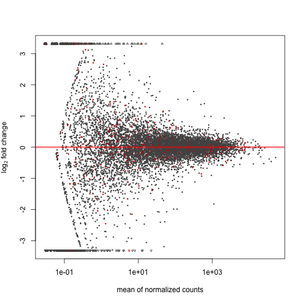

```r
> plotMA(results)
```

#### Voom & limma

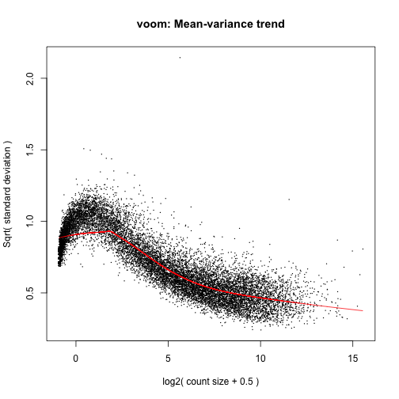

```r
> library(limma)
> norm.factor <- calcNormFactors(dat)
> dat.voomed <- voom(dat, design, plot = TRUE, lib.size = colSums(dat) * norm.factor)
```

```r
> dat.voomed
```

```
An object of class "EList"
$E
                   SRX033480 SRX033488 SRX033481 SRX033489 SRX033482
ENSMUSG00000000001     6.941     6.916     6.720     6.871     6.860
ENSMUSG00000000003    -2.588    -3.625    -2.447    -3.716    -2.585
ENSMUSG00000000028    -2.588    -2.040    -2.447    -2.132    -1.000
ENSMUSG00000000031    -2.588    -3.625    -2.447    -3.716    -2.585
ENSMUSG00000000037    -2.588    -2.040    -0.862    -0.257    -2.585
                   SRX033490 SRX033483 SRX033476 SRX033478 SRX033479
ENSMUSG00000000001    6.8447      6.87    6.4977    6.8899     6.279
ENSMUSG00000000003   -3.8055     -2.89   -3.3773   -3.3036    -3.049
ENSMUSG00000000028   -2.2205     -2.89    0.5296    0.3968    -1.465
ENSMUSG00000000031   -3.8055     -2.89   -3.3773   -3.3036    -3.049
ENSMUSG00000000037   -0.6355     -2.89   -3.3773   -3.3036    -3.049
                   SRX033472 SRX033473 SRX033474 SRX033475 SRX033491
ENSMUSG00000000001    6.2110     6.615     6.397     6.693     6.737
ENSMUSG00000000003   -3.0250    -3.236    -2.877    -2.855    -3.873
ENSMUSG00000000028   -1.4400    -1.651    -1.292    -1.270    -2.288
ENSMUSG00000000031   -3.0250    -3.236    -2.877    -2.855    -3.873
ENSMUSG00000000037    0.1449    -1.651    -1.292    -2.855    -2.288
                   SRX033484 SRX033492 SRX033485 SRX033493 SRX033486
ENSMUSG00000000001    6.9151     6.855     6.375     6.718     6.760
ENSMUSG00000000003   -3.2025    -3.825    -2.827    -3.849    -2.952
ENSMUSG00000000028   -0.8806    -2.240    -1.242    -0.679    -1.367
ENSMUSG00000000031   -3.2025    -3.825    -2.827    -3.849    -2.952
ENSMUSG00000000037   -0.8806    -2.240    -1.242    -2.264    -1.367
                   SRX033494
ENSMUSG00000000001     7.005
ENSMUSG00000000003    -3.739
ENSMUSG00000000028    -0.280
ENSMUSG00000000031    -3.739
ENSMUSG00000000037    -1.417
36531 more rows ...

$weights
       [,1]   [,2]   [,3]   [,4]   [,5]   [,6]   [,7]   [,8]   [,9]  [,10]
[1,] 15.907 19.293 15.443 19.597 15.899 19.891 16.895 18.482 18.240 17.413
[2,]  1.632  1.547  1.632  1.531  1.632  1.517  1.632  1.595  1.612  1.632
[3,]  1.469  1.383  1.488  1.378  1.470  1.374  1.436  1.397  1.402  1.421
[4,]  1.632  1.547  1.632  1.531  1.632  1.517  1.632  1.595  1.612  1.632
```

[output cut: 12 more lines]

```
[5,]  1.377
36531 more rows ...

$design
  (Intercept) group2
1           1      0
2           1      0
3           1      0
4           1      0
5           1      0
16 more rows ...

$targets
[1] 3006197 6166939 2726341 6572633 3000692
16 more rows ...
```

```r
> fit <- lmFit(dat.voomed, design)
> fit <- eBayes(fit)
> topTable(fit)
```

```
                   X.Intercept.    group2 AveExpr      F   P.Value
ENSMUSG00000025867       12.477 -0.013979  12.471 154234 2.584e-55
ENSMUSG00000022892       12.268 -0.086479  12.223 138459 1.103e-54
ENSMUSG00000037852       12.321 -0.237470  12.194 134826 1.576e-54
ENSMUSG00000042700       10.716 -0.048029  10.692 133973 1.717e-54
ENSMUSG00000029461       10.300  0.020715  10.311 121795 6.182e-54
ENSMUSG00000020658        9.610 -0.019628   9.601 119935 7.604e-54
ENSMUSG00000060261        9.469 -0.015743   9.461 117841 9.635e-54
ENSMUSG00000032549       11.904  0.003545  11.905 117324 1.022e-53
ENSMUSG00000024462       10.227 -0.138929  10.153 116767 1.090e-53
ENSMUSG00000030102       12.085 -0.026149  12.073 112155 1.874e-53
                   adj.P.Val
ENSMUSG00000025867 9.442e-51
ENSMUSG00000022892 1.568e-50
ENSMUSG00000037852 1.568e-50
ENSMUSG00000042700 1.568e-50
ENSMUSG00000029461 4.424e-50
ENSMUSG00000020658 4.424e-50
ENSMUSG00000060261 4.424e-50
ENSMUSG00000032549 4.424e-50
ENSMUSG00000024462 4.424e-50
ENSMUSG00000030102 6.417e-50
```

### Take-home exercise

Choose a specific threshold for the adjusted p value, find the genes identified as differentially expressed using each of edgeR, DESeq and voom+limma. Compare the number of genes in these 3 lists, and draw a venn digram demonstrating the overlap (if any!).

(1) cut-off value for adjusted p-value: 1e-10

```r
> cutoff <- 1e-10
```

(2) differentially expressed genes using **edgeR**.

> Follow the procedures above

```r
> edgeRHits <- tt.glm$table[tt.glm$table$FDR < cutoff, ]
```

There are 112 which are significant. Show the first 5 such genes.

```r
> edgeRHits[1:5, ]
```

```
                    logFC logCPM    LR    PValue       FDR
ENSMUSG00000020912 -5.187  3.155 401.8 2.238e-89 8.177e-85
ENSMUSG00000050141 -5.363  2.319 311.6 9.787e-70 1.788e-65
ENSMUSG00000035775 -4.543  2.674 298.0 9.042e-67 1.101e-62
ENSMUSG00000015484 -1.968  4.307 282.5 2.113e-63 1.930e-59
ENSMUSG00000024248 -3.152  3.463 277.0 3.337e-62 2.438e-58
```

(3) differentially expressed genes using **DESeq**

> Follow the procedures above and be carefull about the “NAs” in the `padj` column.

```r
> DESeqHits <- results[results$padj < cutoff & !is.na(results$padj), ]
```

There are 76 which are significant. Show the first 5 such genes.

```r
> DESeqHits[1:5, ]
```

```
                     id baseMean baseMeanA baseMeanB foldChange
1004 ENSMUSG00000006403   339.60    472.78    218.52     0.4622
1623 ENSMUSG00000015484    90.30    148.39     37.49     0.2527
1676 ENSMUSG00000015852    39.55     68.79     12.97     0.1885
2082 ENSMUSG00000019232   111.45    183.14     46.28     0.2527
2645 ENSMUSG00000020629   152.21     90.53    208.28     2.3006
     log2FoldChange      pval      padj
1004         -1.113 3.804e-14 8.687e-12
1623         -1.985 4.882e-39 1.134e-35
1676         -2.407 1.378e-35 1.920e-32
2082         -1.985 2.034e-17 6.442e-15
2645          1.202 3.713e-18 1.262e-15
```

(4) differentially expressed genes using **voom+limma**

> Follow the procedures above

```r
> voomlimmaHits <- topTable(fit, coef = "group2", p.value = cutoff, n = Inf)
```

There are 18 which are significant. Show the first 5 such genes.

```r
> voomlimmaHits[1:5, ]
```

```
                    logFC AveExpr      t   P.Value adj.P.Val     B
ENSMUSG00000015484 -1.995  3.9635 -20.49 6.099e-18 8.457e-14 30.79
ENSMUSG00000027855  5.343 -0.3132  22.23 7.634e-19 2.789e-14 30.24
ENSMUSG00000030532  1.539  5.3545  19.71 1.626e-17 1.485e-13 30.04
ENSMUSG00000023236  1.420  6.8879  19.36 2.548e-17 1.552e-13 29.64
ENSMUSG00000054354 -5.824 -0.2156 -20.39 6.944e-18 8.457e-14 28.84
```

(5) Draw a venn digram demonstrating the overlap.

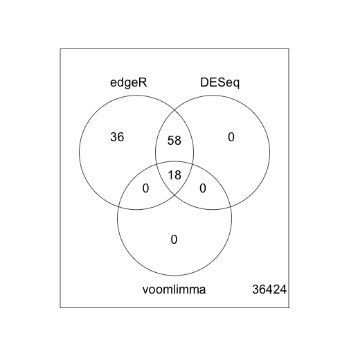

```r
> allGenes <- rownames(dat)
> geneHits <- data.frame(edgeR = allGenes %in% rownames(edgeRHits),
+                        DESeq = allGenes %in% DESeqHits$id,
+                        voomlimma = allGenes %in% rownames(voomlimmaHits))
> rownames(geneHits) <- allGenes
> vennDiagram(vennCounts(geneHits))
```